# Prediction Assignment Writeup

Yu-Fu Wang

2017/8/16

# Synopsis

The project goal is to predict the manner in which they did the exercise by using data from accelerometers on the belt, forearm, arm, and dumbell of 6 participants. We will create a report describing how to build the model, how to use cross validation, the expected out of sample error, and why we made the choices we did. We will also use our prediction model to predict 20 different test cases.

# Data Processing

## 1.load data

```r
library(caret)
library(randomForest)
library(rpart)
```

```r
library(rpart.plot)
#define seed
set.seed(1001)

#setup working directory
setwd("F:\\Big data\\Course8\\week4")

#load the training and test data
trainingset <-read.csv("pml-training.csv", na.strings = c("NA", "DIV/0!", ""))
testingset <-read.csv("pml-testing.csv", na.strings = c("NA", "DIV/0!", ""))


dim(trainingset)
```

```
## [1] 19622   160
```

```r
dim(testingset)
```

```
## [1]  20 160
```

## 2.clean data

### filter out the columns which contain Na

```r
trainingset <- trainingset[,colSums(is.na(trainingset)) == 0]
testingset <- testingset[,colSums(is.na(testingset)) == 0]
```

### remove columns wich I believe there’s no outcome on the class

```r
trainingset <- trainingset[,-c(1:7)]
testingset <- testingset[,-c(1:7)]

dim(trainingset)
```

```
## [1] 19622    53
```

```r
dim(testingset)
```

```
## [1] 20 53
```

# Prediction

```r
#partition the training data
subSamples <- createDataPartition(y=trainingset$classe, p=0.75, list = FALSE)
subTraining <- trainingset[subSamples,]
subTesting <- trainingset[-subSamples,]
```

## 1st prediction model: Decision Tree

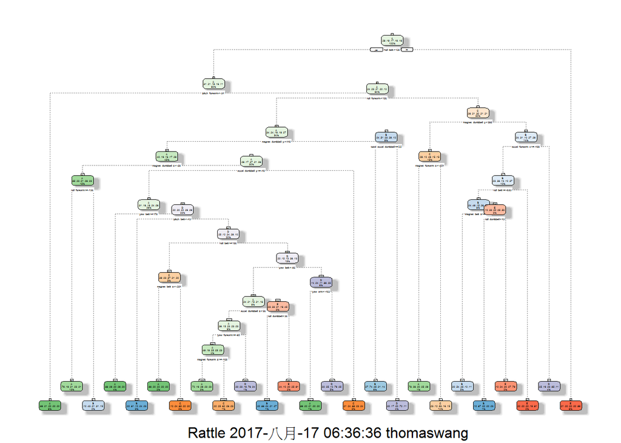

```r
library(rpart)

modFit <- rpart(classe ~ ., data=subTraining, method = "class")

# plot the decision tree
rattle::fancyRpartPlot(modFit)
```

```r
# predic
prediction1 <- predict(modFit, subTesting, type="class")

# test results on subTesting data set
confusionMatrix(prediction1, subTesting$classe)
```

```
## Confusion Matrix and Statistics
##
##           Reference
## Prediction    A    B    C    D    E
##          A 1269  142   20   33   21
##          B   49  590   92   87   90
##          C   34  124  699  116  122
##          D   17   67   44  509   53
##          E   26   26    0   59  615
##
## Overall Statistics
##
##                Accuracy : 0.7508
##                  95% CI : (0.7385, 0.7629)
##     No Information Rate : 0.2845
##     P-Value [Acc > NIR] : < 2.2e-16
##
##                   Kappa : 0.6841
##  Mcnemar's Test P-Value : < 2.2e-16
##
## Statistics by Class:
##
##                      Class: A Class: B Class: C Class: D Class: E
## Sensitivity            0.9097   0.6217   0.8175   0.6331   0.6826
## Specificity            0.9384   0.9196   0.9022   0.9559   0.9723
## Pos Pred Value         0.8545   0.6498   0.6384   0.7377   0.8471
## Neg Pred Value         0.9631   0.9102   0.9590   0.9300   0.9315
## Prevalence             0.2845   0.1935   0.1743   0.1639   0.1837
## Detection Rate         0.2588   0.1203   0.1425   0.1038   0.1254
## Detection Prevalence   0.3028   0.1852   0.2233   0.1407   0.1480
## Balanced Accuracy      0.9241   0.7707   0.8599   0.7945   0.8274
```

## 2nd prediction model: Random Forest

```r
modFit2 <- randomForest(classe ~., data=subTraining, method="class")

# predict
prediction2 <- predict(modFit2, subTesting, type = "class")

#test the result on the subTesting data set
confusionMatrix(prediction2, subTesting$classe)
```

```
## Confusion Matrix and Statistics
##
##           Reference
## Prediction    A    B    C    D    E
##          A 1394    4    0    0    0
##          B    0  944    3    0    0
##          C    0    1  852    7    4
##          D    0    0    0  797    2
##          E    1    0    0    0  895
##
## Overall Statistics
##
##                Accuracy : 0.9955
##                  95% CI : (0.9932, 0.9972)
##     No Information Rate : 0.2845
##     P-Value [Acc > NIR] : < 2.2e-16
##
##                   Kappa : 0.9943
##  Mcnemar's Test P-Value : NA
##
## Statistics by Class:
##
##                      Class: A Class: B Class: C Class: D Class: E
## Sensitivity            0.9993   0.9947   0.9965   0.9913   0.9933
## Specificity            0.9989   0.9992   0.9970   0.9995   0.9998
## Pos Pred Value         0.9971   0.9968   0.9861   0.9975   0.9989
## Neg Pred Value         0.9997   0.9987   0.9993   0.9983   0.9985
## Prevalence             0.2845   0.1935   0.1743   0.1639   0.1837
## Detection Rate         0.2843   0.1925   0.1737   0.1625   0.1825
## Detection Prevalence   0.2851   0.1931   0.1762   0.1629   0.1827
## Balanced Accuracy      0.9991   0.9970   0.9968   0.9954   0.9965
```

# Conclusion

## 1.Why we made the choice

Compare above two predictions, Random Forest algotihtm is better than Decision Tree. Accuracy for Random Forest model is 0.996 and accuracy for Decision Tree is 0.751. The Random Forest model is chosen.

## 2.What we think the expected out of sample error is

The expected out-of-sample error will correspond to the expected number of missclassified observations/total observations in the Test data set, which is the quantity: 1-accuracy found from the cross-validation data set. The accuracy of the Random Forest model is 0.996. The expected out-of-sample error is estimated at 0.4%.

# 3.Use our prediction model to predict 20 different test cases

```r
prediction_final <- predict(modFit2, testingset, type="class")
prediction_final
```

```
##  1  2  3  4  5  6  7  8  9 10 11 12 13 14 15 16 17 18 19 20
##  B  A  B  A  A  E  D  B  A  A  B  C  B  A  E  E  A  B  B  B
## Levels: A B C D E
```